# FUZE Tea Product Launch

Abhishek Paitya, Anoop S, Chirag Khatri

March 13, 2019

# 1 Introduction

# 2 Problem Overview

Coca-Cola, like other major CPG manufacturers, works in tandem with bottlers and retailers to sell their products. They do not have a direct touch-point with the final customer of their products and as such it is difficult for them to gather insights at a customer level.

Coca-Cola wants to gain customer level insights from their Fuze Tea launch in the US Market. Further, it wants to leverage these learnings to simulate the performance of Fuze in European Market and also understand how different marketing activities will impact this pattern.

# 3 Executive Summary

This notebook provides an approach to simulate the product launch of FUZE Refreshment Tea in United States in 2013. It uses Agent based modeling and Bayesian networks to portray the decision journey of consumers while purchasing a beverage. A combination of actual data and expert knowledge is used in the simulation. The model can be used to evaluate policy decisions such as:

- Distribution of the marketing spends across channels
- Scale of in-store price reductions on FUZE products

- Granular Marketing data - Actual weekly spends and campaign effectiveness will uncover the real relationship between brand awareness and marketing spends
- Social media data - Posts containing product mentions will help understand consumer sentiment towards the FUZE brand

# 4 Solution Approach

We follow the **Real Games** approach, in order to simulate market behavior from the ground-up by replicating every consumer as an agent and defining their interactions with the product and market in different situations. This simulation will be used to evaluate various policy decisions in a cost-effective manner, once validated. We use Agent Based Modeling (ABM) for simulating agent behavior and Bayesian Networks (BN) to inform consumption decisions of each agent.

## 4.1 What is an Agent?

An agent is an **autonomous individual element** with properties and actions in a computer simulation

In our case, the agents are individual consumers living in the United States with properties like Age, Income, Gender, etc. and who perform the action of purchasing a beverage.

Sample of the agent data:

|  | zip | age | segment | HHIncome | childrenAge | maritalStatus | netWorth | houseOwner | popDensity | homeValue | occupation | education | HHSize | STUSAB | STATE_NAME |
| --- | --- | --- | --- | --- | --- | --- | --- | --- | --- | --- | --- | --- | --- | --- | --- |
| 56592 | ZCTA5 94015 | 66-75 Years | active elders | $50,000-$74,999 | No Children Present | Married | $100,000-$249,999 | Home Owner | 3,016-5,440 | $125,000-$149,999 | Craftsman/Blue Collar | Completed High School | Three Person Household | CA | California |
| 57969 | ZCTA5 95051 | 76+ Years | active elders | $50,000-$74,999 | No Children Present | Married | $10,000-$24,999 | Home Owner | 1,016-3,015 | $200,000-$299,999 | Professional/Technical | Completed College | Two Person Household | CA | California |
| 17701 | ZCTA5 28786 | 36-45 Years | transition time | <$15,000 | No Children Present | Married | $50,000-$99,999 | Renter | 84-1,015 | $50,000-$99,999 | Professional/Technical | Completed High School | Three Person Household | NC | North Carolina |
| 51371 | ZCTA5 90003 | 30-35 Years | flying solo | $40,000-$49,999 | No Children Present | Single | <$1 | Home Owner | 3,016-5,440 | $500,000+ | Housewife | Completed High School | One Person Household | CA | California |
| 39698 | ZCTA5 65658 | 36-45 Years | jumbo families | $75,000-$99,999 | Ages 11-15 | Married | $100,000-$249,999 | Home Owner | 25-83 | $50,000-$99,999 | Clerical/White Collar | Completed Graduate School | Five+ Person Household | MO | Missouri |

## 4.2 What is the Environment for the agents?

The consumer agent interacts with other agents and their environment to make purchase decisions. Their environment comprises of the following entities:

- **Other agents**: Other consumers modeled as agents in the simulation
- **The Market**: The agent lives in an environment that emulates the real world.
  - The market includes the 4 major brands producing Ready To Drink (RTD) Iced Tea beverages. These brands are FUZE, Lipton, Arizona, and Snapple.
  - The products are sold in retail stores spread across the country. Retailers group their stores belonging to a region and call the groups of stores Commodity Trade Areas (CTAs).
  - The RTD Tea products being sold in these stores may or may not be on promotion for a particular week depending on the brand and the retail store
- **The Geographical elements**:
  - An agent belongs to a geographical area - ZIP code within a US
  - Purchase decisions of an agent are affected by the temperature in the area
  - Agents have access to retail stores within their area
  - Agents’ purchase decisions are influenced by purchases made by other agents in the region

## 4.3 How does an Agent make purchase decisions?

The brain of the agent, which is its decision-making mechanism is represented, estimated, and implemented in the form of a *Bayesian network*. The Bayesian paradigm, specifically Bayesian networks provide the following advantages which make them the most appropriate tool for this exercise:

- Elegant and rigorous way to fuse data at differing levels of granularity, along with heuristic beliefs.
- Structure and parameters of the network can be learnt from data, where available.
- Where data is unavailable, prior beliefs from market research studies or opinion from a panel of experts can be incorporated in a consistent framework.
- The network can be constantly validated and updated, allowing for continuous calibration based on real observed evidence - this includes validation of structure of the model & prior beliefs, as well incorporation of new evidence.
- Provides a framework to identify and quantify causal effects from observational data, through the theory of causal calculus.

This paradigm allows for businesses to estimate true cause-effect relationships, and hence make more informed policy decisions, without the need for Randomized Controlled Trials (RCTs) in all cases. The amount of field experimentation can be reduced substantially, therefore leading to generating more cost-effective signals for decision-making.

### 4.3.1 Network Structure

[interactive chart not shown]

**Segment**  
The network consists of 18 nodes connected with arcs describing a cause-effect relationship. The above network structure is created using research and domain knowledge. Every agent is assigned to one of the customer **Segment** or **Life Stage Group** defined by PersonicX:

1. Beginnings
2. Taking Hold
3. Transition Time
4. Flying Solo
5. Family Focused
6. Mixed Singles
7. Cash & Careers
8. Jumbo Families
9. Middling Singles
10. Mixed Middlers
11. Fortunes & Families
12. Flush Families
13. True Blues
14. Our Turn
15. Mature Wealth
16. Aging Upscale
17. Modest Means
18. Mature Rustics
19. Golden Years
20. Active Elders
21. Leisure Buffs

**Part of Day**  
A day in the simulation is divided into 6 parts of the day. Product sales are predicted at this level. Upper bounds of hours are non-inclusive:

1. Early_Morning: 3 AM to 8 AM
2. Mid_Morning: 8 AM to 11 AM
3. Midday: 11 AM to 12 PM
4. Afternoon: 12 PM to 5 PM
5. Early_Evening: 5 PM to 7 PM
6. Evening: 7 PM to 3 AM

**Drinking Moment**  
Depending on the **segment**, **time of day** and **weekday/weekend**, each agent gets a **Drinking Moment** assigned to them for that part of the day. A Drinking Moment is defined as a combination of occasion and need to drink a beverage. There are 14 drinking moments:

1. Nourishing Breakfast
2. Energizing Breakfast
3. Nurturing Meals at Home
4. Comforting Meals at Home
5. My Meal/Snack Time
6. Routine Habits at Home
7. Mental Refreshment at Home
8. Daily Unwind
9. Relaxing Screen Time
10. Fun Meals away from Home
11. Time Out at Work/School
12. Energy on the Run
13. Socializing
14. Physical Recovery

**Beverage Category**  
Based on the agent’s **Drinking Moment** and corresponding **Temperature**, they pick a **Beverage Category**. There are 20 Beverage Categories as described below. We are focusing on **RTD Tea** category that contains FUZE Refreshment Tea:

1. Beer
2. Bulk Water
3. Dairy Alternative
4. Freshly Squeezed Juice
5. Light Core Sparkling
6. Noncarbonated Unflavored Pkg Water
7. NRTD Coffee
8. NRTD Juice & Juice Drinks <100% Juice
9. NRTD Tea
10. Other Alcoholic Beverage
11. Other Non-Alcoholic Drinks
12. Other Soy Beverages
13. Plain Milk
14. Plain Milk From Own Cow/Goat
15. Regular Core Sparkling
16. RTD Juices/Nectars
17. RTD Tea
18. Sports Drinks
19. Tap Water
20. Wine/Champagne

**Promotion**

After choosing a Beverage Category, the agent looks into promotional price reductions offered by Fuze as well as the competitors brands - Arizona, Lipton and Snapple. Promotion is calculated based on the difference between the average weekly price for the year and the price for that week for each Commodity Trade Area (CTA) and brand. The thresholds are as below:

- None: **0% to 10%** difference in average weekly price and current week’s price
- Light: **10% to 25%** difference in average weekly price and current week’s price
- Deep: **More than 25%** difference in average weekly price and current week’s price

*Fuze Promotion Index* is a latent variable which is combination of promotions on Fuze products as well as the promotions on the three competitor brands’ products - Arizona, Lipton and Snapple. The value of Fuze Promotion Index - None, Light or Deep describes the degree of promotions on Fuze products with respect to its competitors.

**Product Adoption**  
An agent’s decision to purchase a product is also influenced by their **Product Adoption Segment**. Each agent can be said to be in any one of the following product adoption segments (related to FUZE) at any given time:

- Never tried
- Would never try/Hate it
- Consume sometimes
- Love it
- Absolutely Love it

Agent moves from one product adoption segment to the other based on their FUZE purchases

| Product adoption stage/Reasons for consumption | Social group | Novelty seeking behavior | Brand awareness (New product, needs to be aware of brand) | Promotions | Availability of product and flavors |
| --- | --- | --- | --- | --- | --- |
| Never tried | High Impact | High Impact | High Impact | High Impact | - |
| Would never try/Hate it | Low Impact | - | Low Impact | Medium Impact | Medium Impact |
| Sometimes | Medium Impact | - | Low Impact | High Impact | Medium Impact |
| Love it | - | - | - | High Impact | High Impact |
| Absolutely love it | - | - | - | Medium Impact | High Impact |

**Brand Awareness**  
An agent is exposed to marketing activities by brands. Their brand awareness index measures their level of familiarity with the FUZE brand. The brand awareness index goes up with every consumer touchpoint across any marketing channel. The effectiveness of each marketing channel is as below:

*Effectiveness of marketing channels*

| Marketing Channel | Recalled % |
| --- | --- |
| Coupons | 14 % |
| Digital Website | 18 % |
| Field Sampling | 18 % |
| Out Of Home | 39 % |
| Radio | 21 % |
| Shopper Marketing | 35 % |

The recalled % is used as a proxy for the channel’s effectiveness.

The brand awareness level goes down over time, if the the consumer is not exposed to any marketing touchpoint. Decay rate of brand awareness:

**R = exp(-t/S)**

where:

R = probability of recall (retrievability of memory)  
S = strength of a memory trace (stability of memory)  
t = time

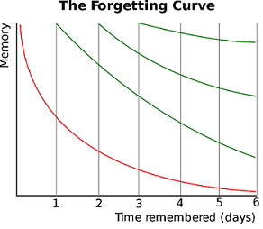

An agent’s Brand Awareness Index for FUZE can have the following levels:

- Low
- Medium
- High

*Weekly Marketing Spends*: Data for yearly marketing spends across the following marketing channels is available for 2013:

- Radio
- Out Of Home
- Digital Website
- Coupons
- Field Sampling
- Shopper Marketing

**Social Index**  
An agent’s social index value (Low, Medium, or High) captures the number of FUZE sales made by other agents in their vicinity. It gets higher if more agents in the same ZIP purchase FUZE products, and lower if there are less FUZE sales happening in the ZIP.

**Purchase**  
Based on all these factors an agent is finally assigned a probability to make a **Purchase**. They can purchase either a FUZE product or a competitor product, or they can choose to purchase a product from a beverage category other than RTD Tea.

### 4.3.2 State Chart

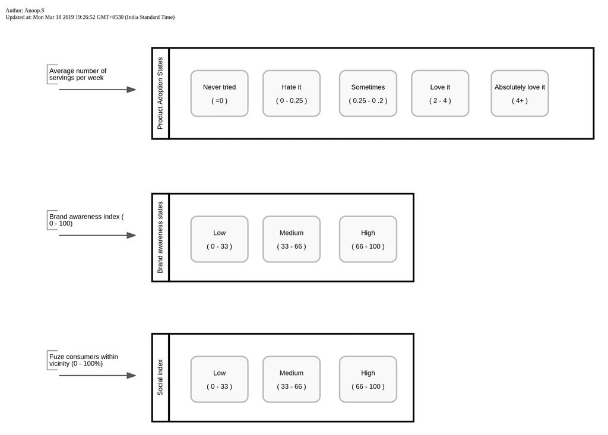

## 4.4 Estimation

The probability values for the Bayesian Network, also known as the parameters, are estimated using a combination of **data** and rules derived from **market research**. The following table lists down the nodes and the source of their parameters.

| Variable Name | Source |
| --- | --- |
| Consumer Demographics | US Census |
| Segment | US Census, Life Stage Groups data |
| Drinking Moments, Beverage Category, Part of Day | Drinking Moments data |
| Price Reduction Promotion across brands | Sales data |
| Temperature | Open Source data |
| Brand Awareness, Novelty Seeking Index, Social Index, Product Adoption in Vicinity, Fuze Promotion Index | Rules |
| Purchase | Sales data |
| Marketing Data | BGS and rules |

# 5 Simulation and Validation

## 5.1 Simulation

Once the Bayesian Network model is created and its parameters are estimated, we simulate consumers’ purchase decision journey using the model. A number of agents (50K) are randomly sampled from the US population and their RTD Tea purchase patterns are observed over the course of one year - 2013. The results are then extrapolated for the entire population.

The Weekly sales prediction results of the simulation are displayed below:

```r
kable(head(read.csv("./data/simulatedUnitsSold.csv"), 10))
```

| X | Fuze_Units_Purchased | Non_Fuze_Units_Purchased | Date | Part_Of_Day | Week |
| --- | --- | --- | --- | --- | --- |
| 1 | 3 | 98 | 2013-01-01 | Early_Morning | 2013-01-05 |
| 2 | 3 | 107 | 2013-01-01 | Mid_Morning | 2013-01-05 |
| 3 | 4 | 168 | 2013-01-01 | Midday | 2013-01-05 |
| 4 | 4 | 171 | 2013-01-01 | Afternoon | 2013-01-05 |
| 5 | 1 | 139 | 2013-01-01 | Early_Evening | 2013-01-05 |
| 6 | 1 | 129 | 2013-01-01 | Evening | 2013-01-05 |
| 7 | 4 | 85 | 2013-01-02 | Early_Morning | 2013-01-05 |
| 8 | 5 | 109 | 2013-01-02 | Mid_Morning | 2013-01-05 |
| 9 | 4 | 176 | 2013-01-02 | Midday | 2013-01-05 |
| 10 | 11 | 174 | 2013-01-02 | Afternoon | 2013-01-05 |

## 5.2 Validation

The simulated values are compared against actual/observed data

### 5.2.1 Comparison of Actual vs Predicted Sales

The following graphs show how the predicted sales compare against actual sales data for FUZE as well as overall RTD Tea Category.

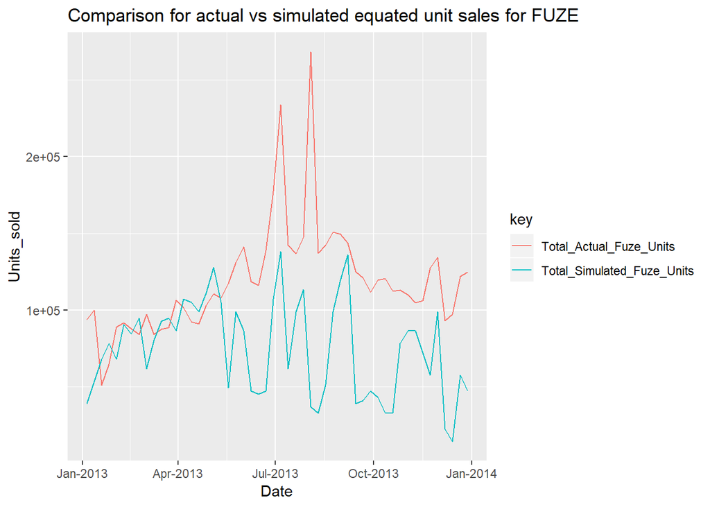

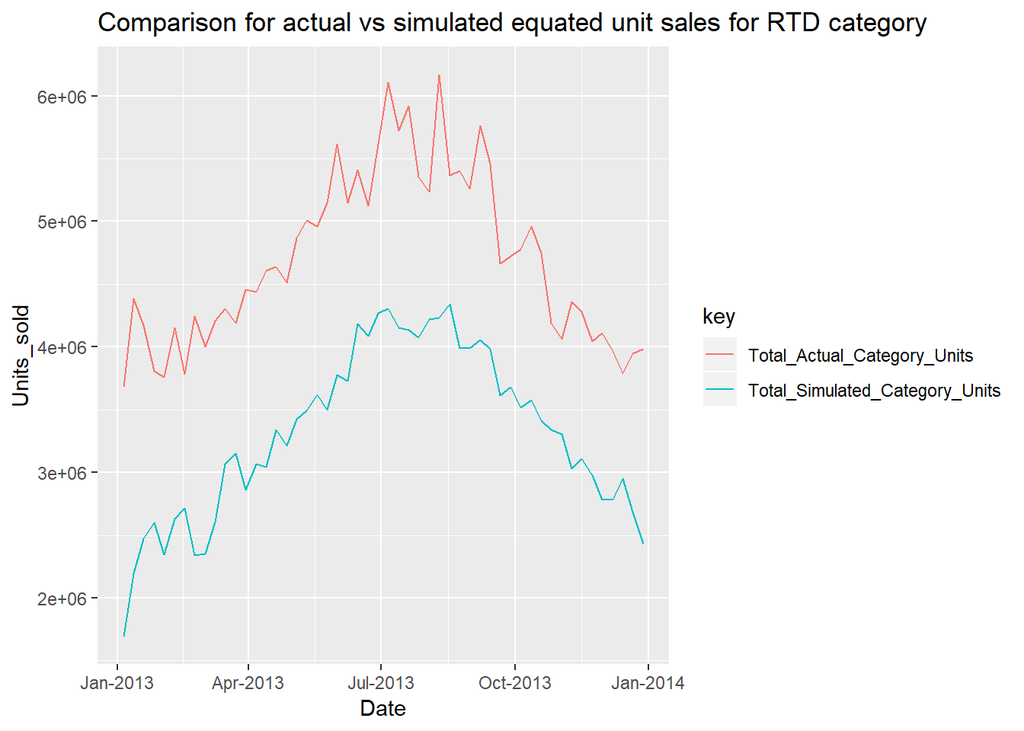

### 5.2.2 Correlation

Following are the correlation coefficients between predicted and actual sales:

**Correlation Coefficient between predicted and actual RTD Category Sales is 0.89**

**Correlation Coefficient between predicted and actual FUZE Refreshment Sales is 0.10.**

### 5.2.3 Prediction Accuracy - MAPE

Following is the MAPE (Mean Absolute Percentage Error) for predicted values when compared to the actual values:

**MAPE for RTD Category Sales prediction - 29.87**

**MAPE for FUZE Refreshment Sales prediction - 37.76**